# Part II - Loan Data from Prosper

## Dataset Overview

This data set contains 113,937 loans with 81 variables on each loan from Prosper, including loan amount, borrower rate (or interest rate), current loan status, borrower income, borrower employment status, borrower credit history, and the latest payment information, etc. It covers the period from 9 Nov 2005 to 10 March 2014.

## The Overall Status of the Loans in Prosper

- Half of all loans are in progress when this dataset was obtained.
- 2/3 of all the finished loans are completed.
- The remained 1/3 are cancelled, past due, defaulted, or charged off.

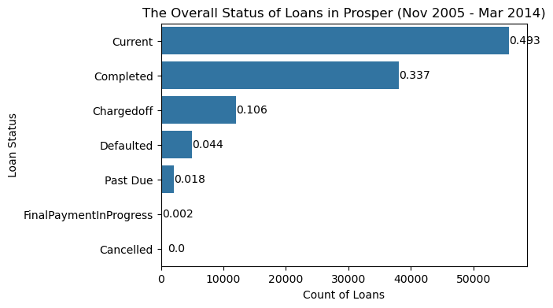

## How Good is Prosper's Interest Rate?

- Most interest rates are in the range between 0.05 and 0.35.
- There is a spike at about 0.31. Apart from that, the plot looks like a bell curve.

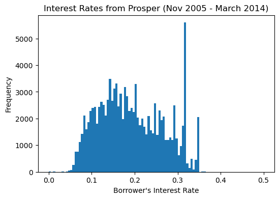

## Who borrow money through Prosper?

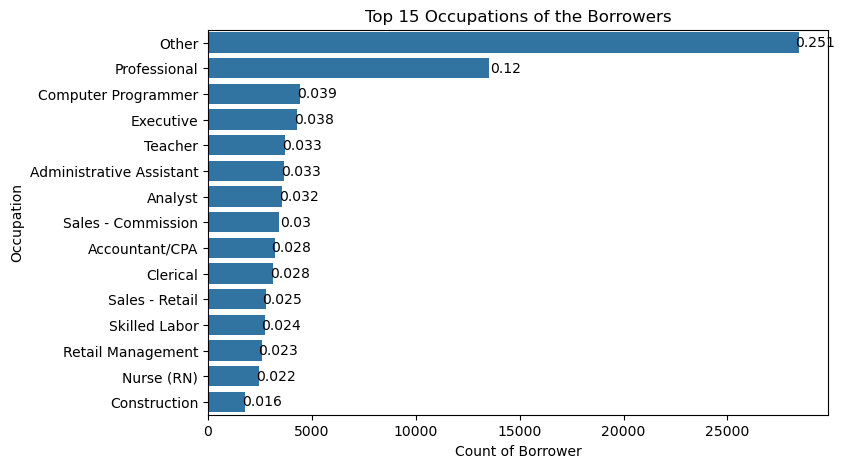

## What Was the Loan Used for?

- More than half of the loans are in the category of "Debt Consolidation".
- This also shows many borrowers of Prosper Loan have already got debts somewhere else but Prosper can help them to manage their debt better so they use its service.

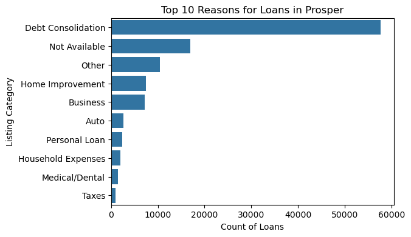

## What Affects Borrowers' Interest Rate?

- Of the factors we explored, Prosper Rating affects borrowers' interest rate most obviously.
- There are 7 ratings from the worst to the best: 'HR', 'E', 'D', 'C', 'B', 'A', 'AA'.
- This measure started from July 2009. For the listings before that date, their raings are 'N/A'.
- The plot suggests a good rating can help reduce the loan's interest rate significantly.

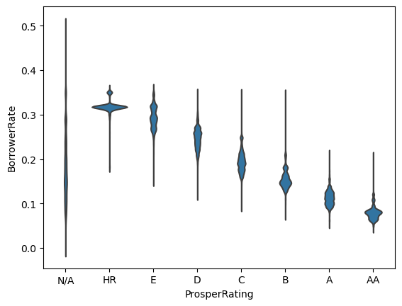